# Dados Videos

Vinnicius Pereira

2025-04-12

```r
library(readxl)
library(ggplot2)
library(summarytools)
library(GGally)
library(ggpubr)
library(mice)
library(shiny)
library(colourpicker)
library(flexdashboard)
library(tidyverse)
library(knitr)
library(rmarkdown)
library(kableExtra)
library(stargazer)
library(shiny)
library(mice)
# Install thematic and un-comment for themed static plots (i.e., ggplot2)
# thematic::thematic_rmd()
```

## Introdução

A base de dados utilizada neste projeto se chama `dados_videos.xlsx` e contém informações sobre vídeos curtos e suas métricas de engajamento. A escolha se deu por apresentar variáveis numéricas suficientes para a análise e por conter dados faltantes, o que é ideal para validar técnicas de imputação. Os resultados esperados incluem uma descrição estatística da base, visualização de padrões de correlação entre variáveis e avaliação da normalidade dos dados, além de aplicar técnicas de imputação e desenvolver um dashboard interativo com Shiny.

## 2. Escolha da Base de Dados

## Importando os dados - Dados Vídeos

```r
dados_videos <- read_excel("dados_videos.xlsx")
View(dados_videos)
```

## Verificando as informações iniciais e uma síntese dos dados inicialmente

```r
head(dados_videos)
```

```
## # A tibble: 6 × 11
##   video_id status_reinvidicacao duracao_video transcricao_video
##      <dbl> <chr>                        <dbl> <chr>
## 1        1 claim                           59 someone shared with me that drone…
## 2        2 claim                           32 someone shared with me that there…
## 3        3 claim                           31 someone shared with me that ameri…
## 4        4 claim                           25 someone shared with me that the m…
## 5        5 claim                           19 someone shared with me that the n…
## 6        6 claim                           35 someone shared with me that gross…
## # ℹ 7 more variables: status_verificacao <chr>, status_video <chr>,
## #   qtd_visualizacoes <dbl>, qtd_curtidas <dbl>, qtd_compartilhamento <dbl>,
## #   qtd_downloads <dbl>, qtd_comentarios <dbl>
```

```r
summary(dados_videos)
```

```
##     video_id    status_reinvidicacao duracao_video   transcricao_video
##  Min.   :   1   Length:4121          Min.   : 5.00   Length:4121
##  1st Qu.:1031   Class :character     1st Qu.:18.00   Class :character
##  Median :2061   Mode  :character     Median :32.00   Mode  :character
##  Mean   :2061                        Mean   :32.25
##  3rd Qu.:3091                        3rd Qu.:47.00
##  Max.   :4121                        Max.   :60.00
##
##  status_verificacao status_video       qtd_visualizacoes  qtd_curtidas
##  Length:4121        Length:4121        Min.   :    35    Min.   :     0
##  Class :character   Class :character   1st Qu.:  4837    1st Qu.:   749
##  Mode  :character   Mode  :character   Median :  9897    Median :  3232
##                                        Mean   :252978    Mean   : 84460
##                                        3rd Qu.:492709    3rd Qu.:122786
##                                        Max.   :999127    Max.   :654588
##                                        NA's   :60        NA's   :60
##  qtd_compartilhamento qtd_downloads   qtd_comentarios
##  Min.   :     0       Min.   :    0   Min.   :   0.0
##  1st Qu.:   105       1st Qu.:    6   1st Qu.:   1.0
##  Median :   695       Median :   45   Median :   9.0
##  Mean   : 16832       Mean   : 1033   Mean   : 343.6
##  3rd Qu.: 18837       3rd Qu.: 1135   3rd Qu.: 289.0
##  Max.   :240154       Max.   :14308   Max.   :8481.0
##  NA's   :60           NA's   :60      NA's   :60
```

## 3. Utilizando a função DESCR() - Estatísticas Descritivas

```r
dados_videos %>%
  dplyr::select(qtd_curtidas, qtd_visualizacoes, qtd_compartilhamento, qtd_downloads, qtd_comentarios) %>%
  summarytools::descr(round.digits = 2, scientific = FALSE, style = "simple", transpose = TRUE) %>%
  kableExtra::kbl(caption = "Estatísticas Descritivas das variáveis objetivo") %>%
  kableExtra::kable_material(c("striped", "hover"))
```

[output not shown]

Estatísticas Descritivas das variáveis objetivo

|  | Mean | Std.Dev | Min | Q1 | Median | Q3 | Max | MAD | IQR | CV | Skewness | SE.Skewness | Kurtosis | N.Valid | N | Pct.Valid |
| --- | --- | --- | --- | --- | --- | --- | --- | --- | --- | --- | --- | --- | --- | --- | --- | --- |
| qtd_comentarios | 343.6183 | 800.395 | 0 | 1 | 9 | 289 | 8481 | 13.3434 | 288 | 2.329314 | 4.0503935 | 0.0384237 | 21.0727231 | 4061 | 4121 | 98.54404 |
| qtd_compartilhamento | 16832.2632 | 32523.935 | 0 | 105 | 695 | 18837 | 240154 | 1018.5462 | 18732 | 1.932238 | 2.7576122 | 0.0384237 | 8.5472782 | 4061 | 4121 | 98.54404 |
| qtd_curtidas | 84460.3282 | 135064.483 | 0 | 749 | 3232 | 122786 | 654588 | 4722.0810 | 122037 | 1.599147 | 1.8265887 | 0.0384237 | 2.6704944 | 4061 | 4121 | 98.54404 |
| qtd_downloads | 1033.0138 | 1976.879 | 0 | 6 | 45 | 1135 | 14308 | 65.2344 | 1129 | 1.913700 | 2.7903970 | 0.0384237 | 9.0269862 | 4061 | 4121 | 98.54404 |
| qtd_visualizacoes | 252977.5592 | 321991.205 | 35 | 4837 | 9897 | 492709 | 999127 | 14434.5936 | 487872 | 1.272805 | 0.9454048 | 0.0384237 | -0.5867198 | 4061 | 4121 | 98.54404 |

## 4. Matriz de Dispersão

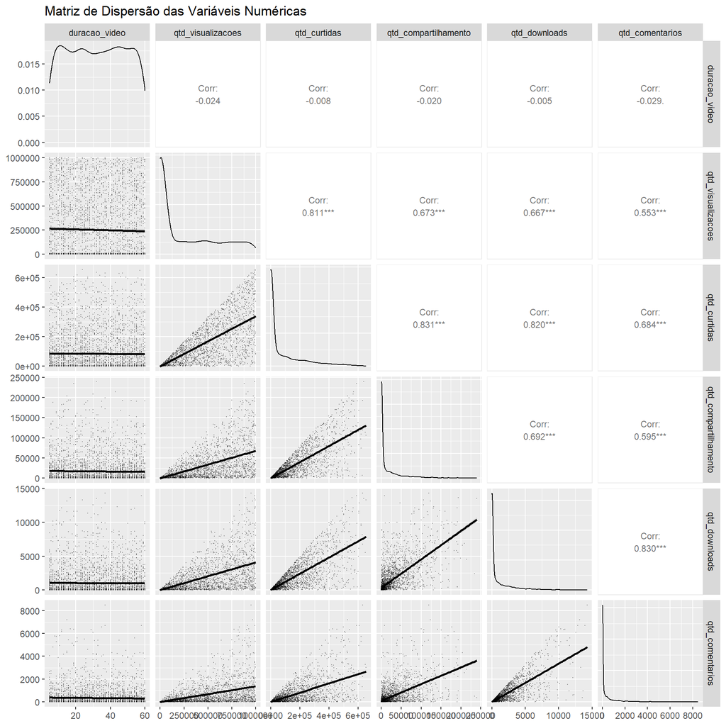

## 5. Análise de Normalidade das Variáveis

### 5A. O que é uma Distribuição Normal?

A distribuição normal, também conhecida como distribuição Gaussiana, é uma distribuição de probabilidade contínua caracterizada por uma curva simétrica em forma de sino. Ela é definida por sua média (μ) e desvio padrão (σ), sendo que: - A média, mediana e moda são iguais; - Aproximadamente 68% dos dados estão a um desvio padrão da média, 95% a dois desvios e 99,7% a três; - É amplamente utilizada em estatística devido ao Teorema Central do Limite, que afirma que, sob certas condições, a média de várias amostras independentes de uma população terá distribuição normal.

## 5B. Histogramas por Variável

O número de *bins* foi escolhido com base na regra de Sturges: → k = 1 + 3,322 log(n) Onde k é o número de classes e n é o número total de observações. num_bins = 14.

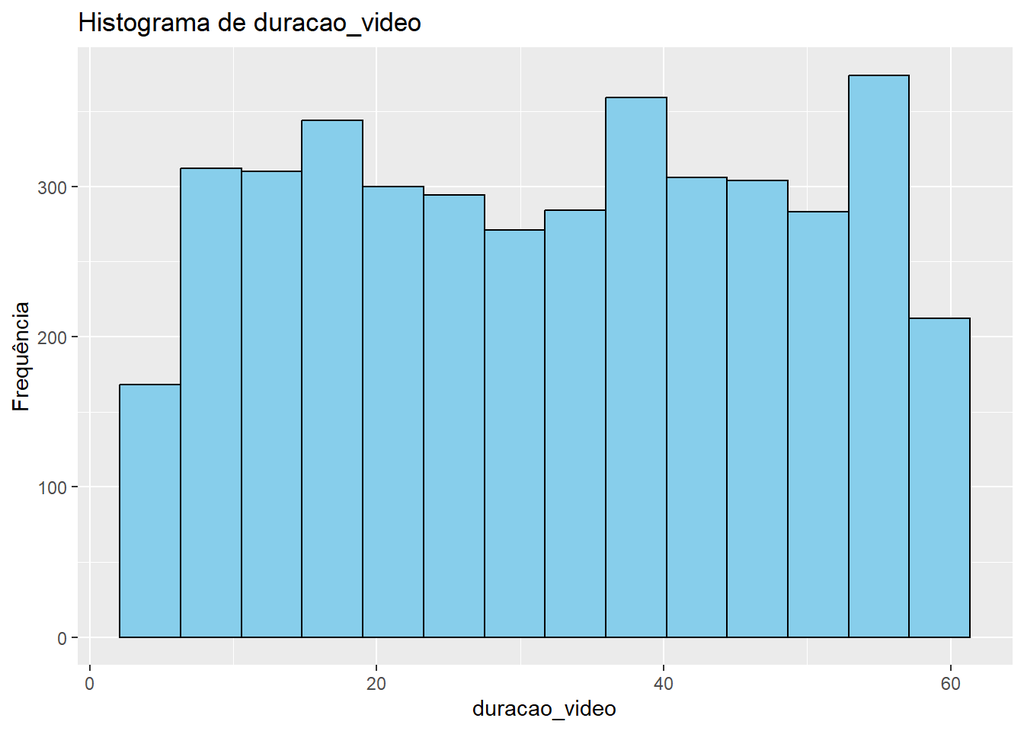

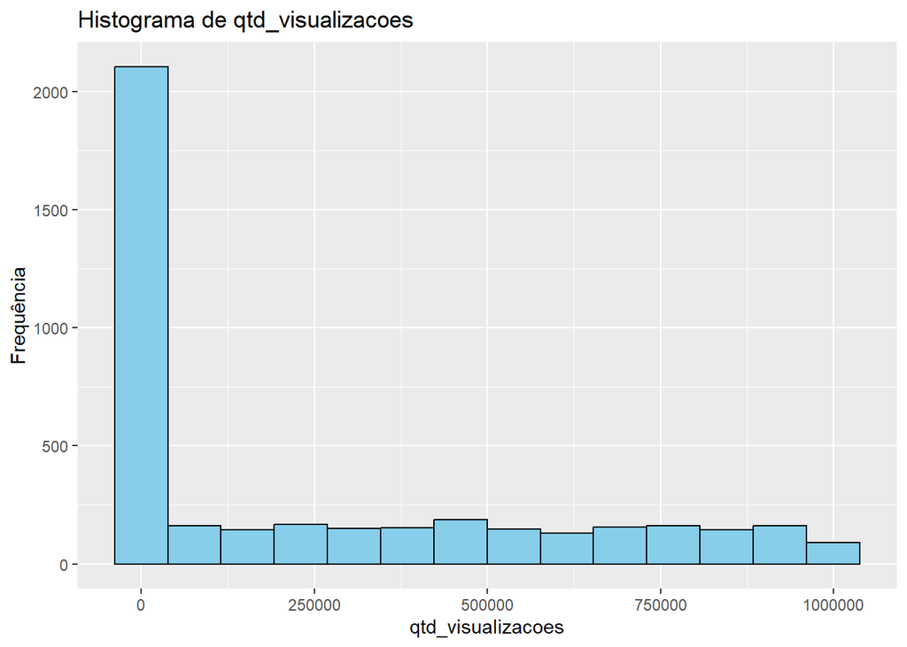

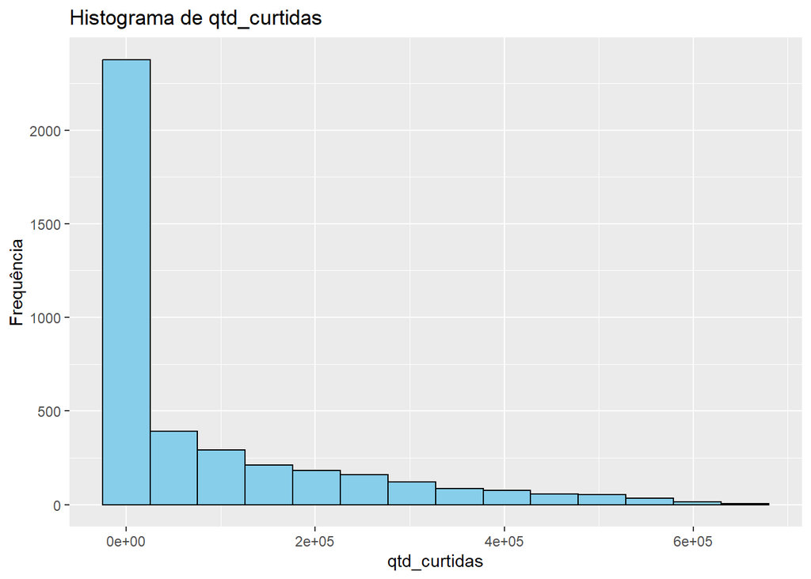

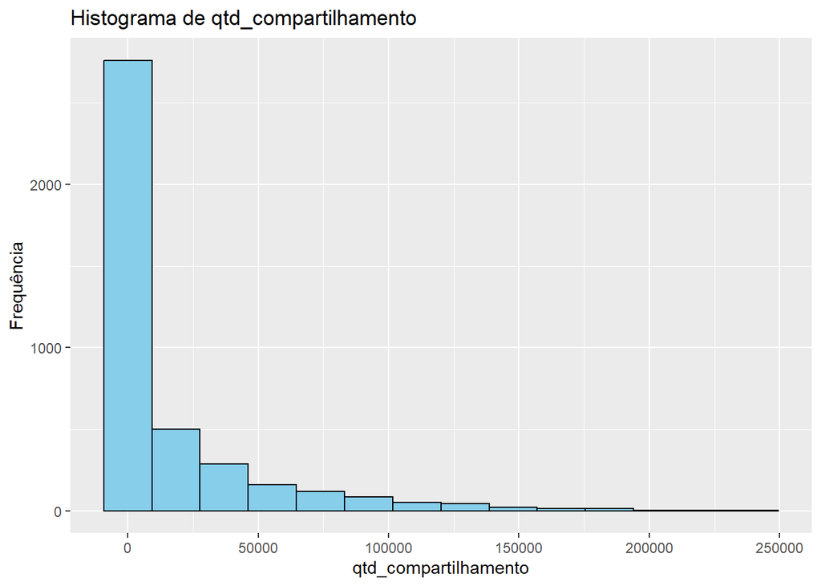

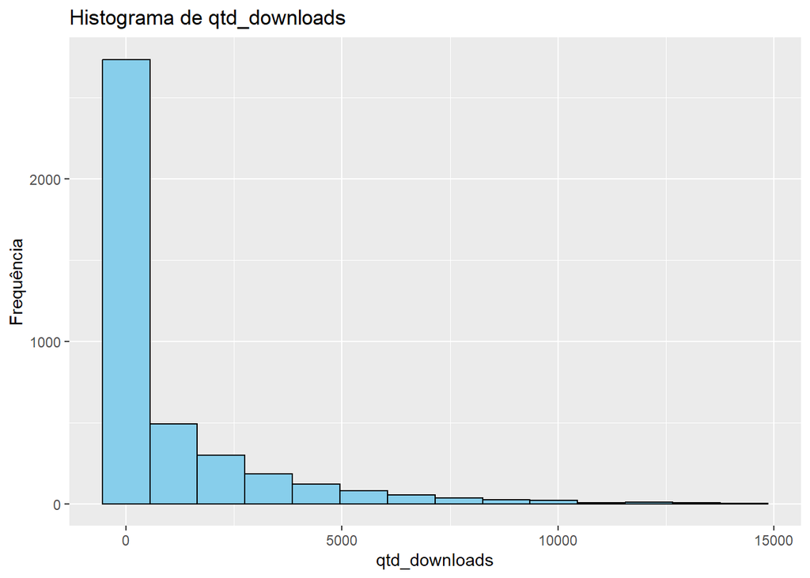

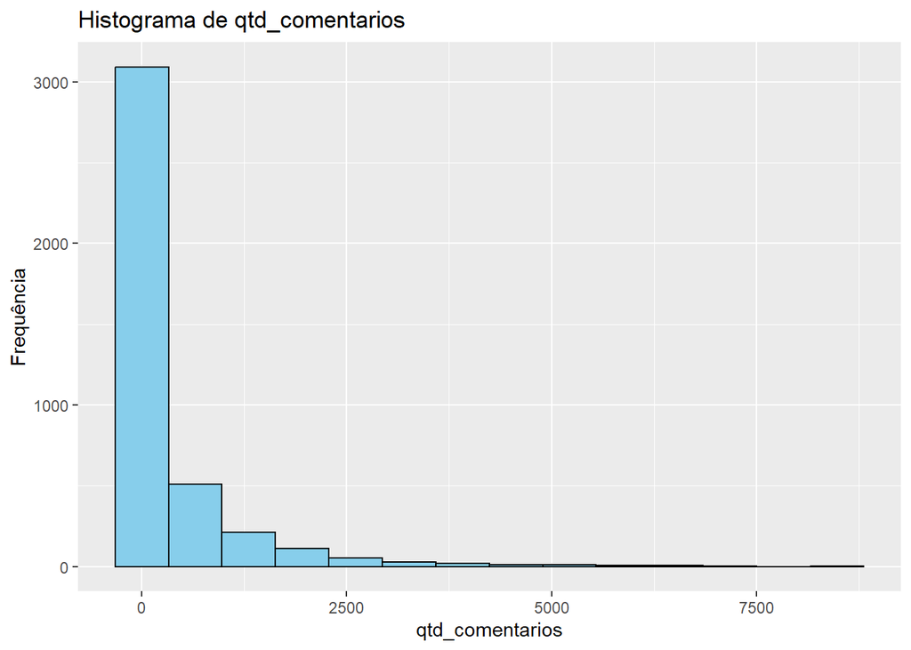

```r
variaveis <- c("duracao_video", "qtd_visualizacoes", "qtd_curtidas",
               "qtd_compartilhamento", "qtd_downloads", "qtd_comentarios")

num_bins <- ceiling(log2(nrow(dados_videos)) + 1)

for (var in variaveis) {
  print(
    ggplot(dados_videos, aes_string(x = var)) +
      geom_histogram(bins = num_bins, fill = "skyblue", color = "black") +
      labs(title = paste("Histograma de", var), x = var, y = "Frequência")
  )
}
```

## 5C. Q-Q Plot por Variável

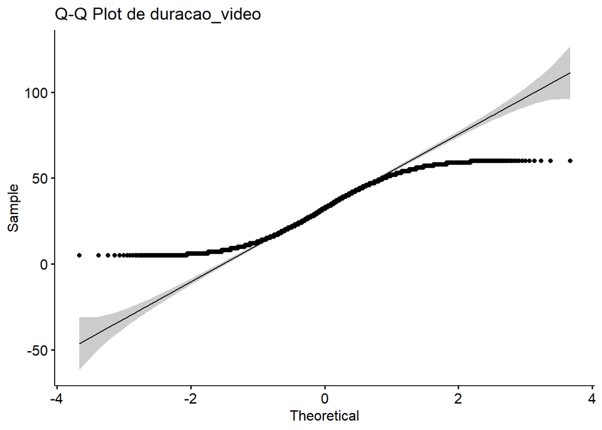

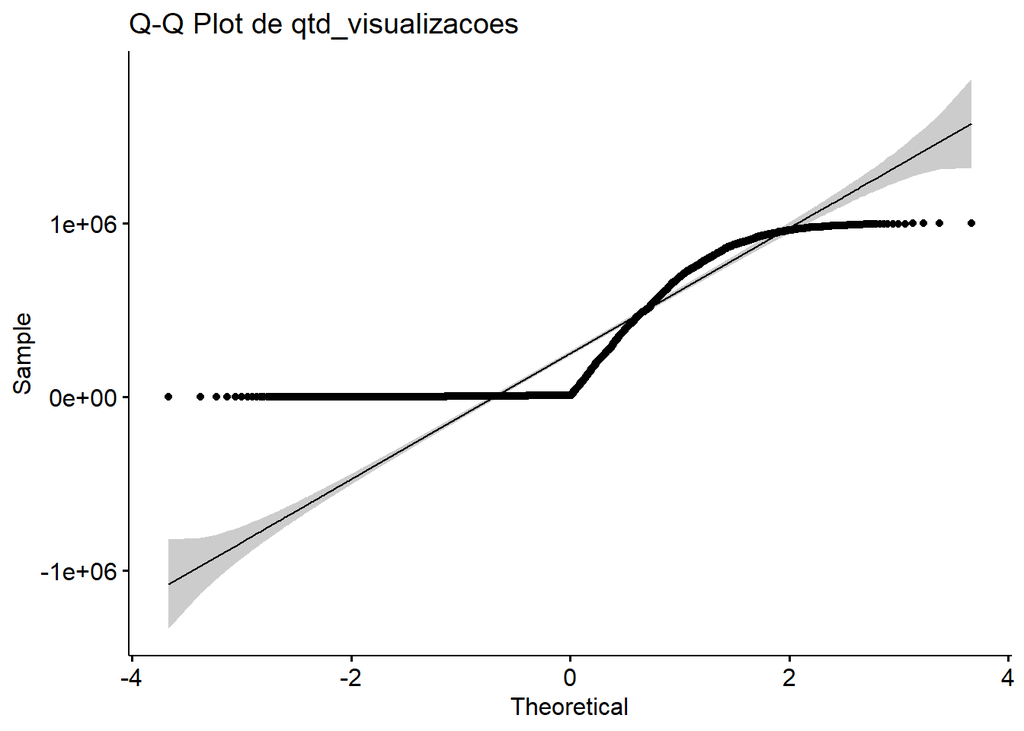

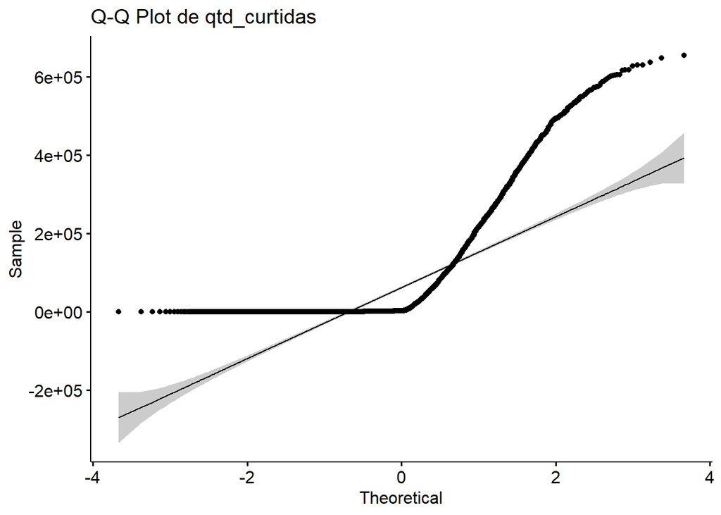

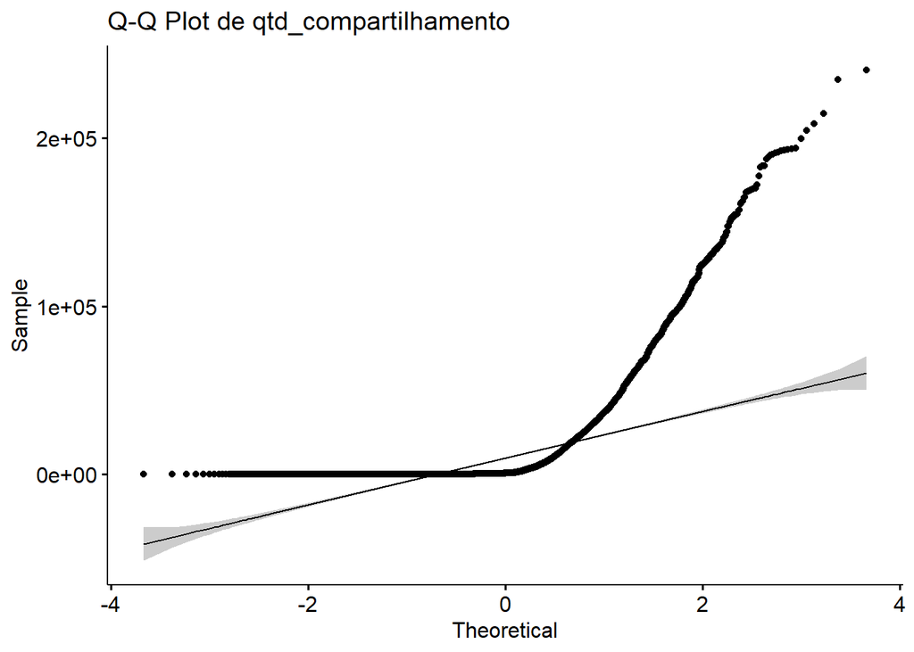

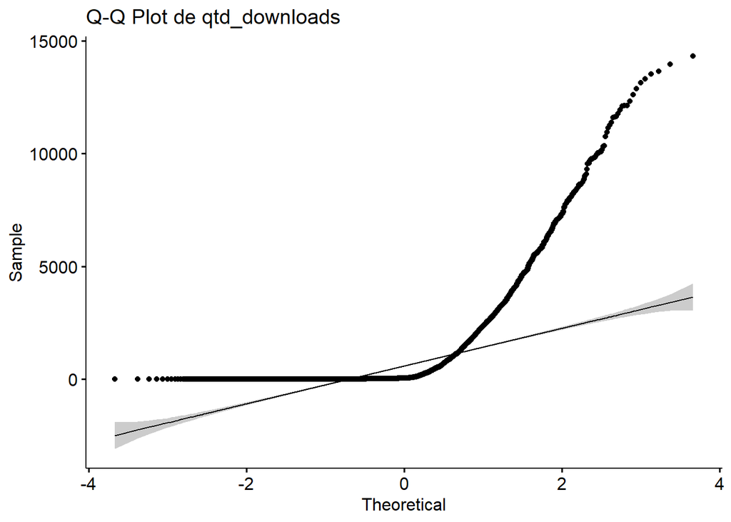

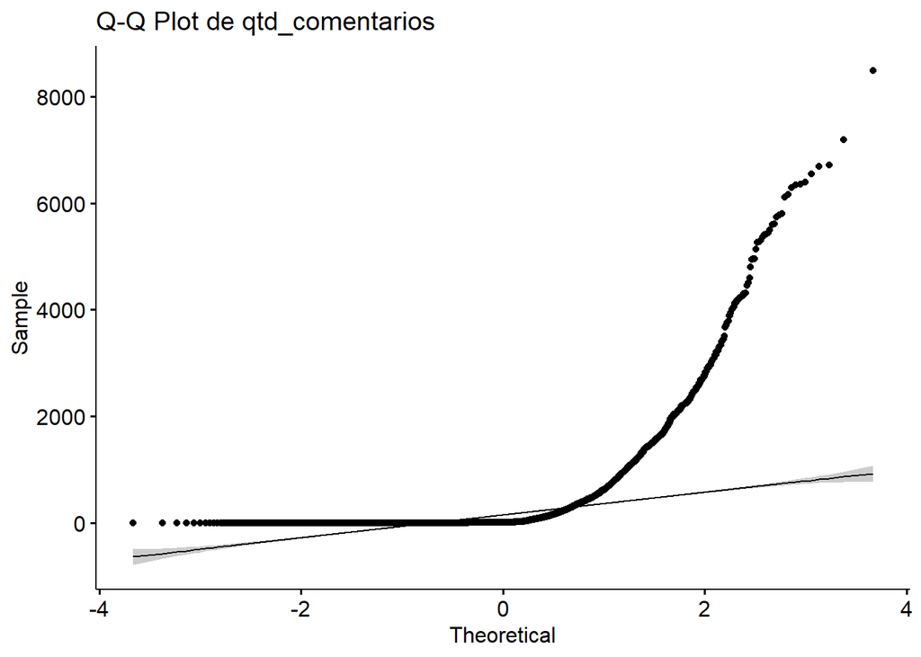

```r
for (var in variaveis) {
  print(
    ggqqplot(dados_videos[[var]], title = paste("Q-Q Plot de", var))
  )
}
```

## 5D e 5E. Teste de Normalidade (Shapiro-Wilk)

**Desta forma, nenhuma das variáveis numéricas da base de dados segue uma distribuição normal.**

Segundo o teste de Shapiro-Wilk, rejeita-se a hipótese nula de normalidade sempre que o p-valor é inferior a 0.05. Neste caso, todos os p-valores são muito inferiores a esse limite, indicando que os dados não são normalmente distribuídos.

```r
shapiro_resultados <- sapply(dados_videos[variaveis], function(x) shapiro.test(x)$p.value)
shapiro_resultados
```

```
##        duracao_video    qtd_visualizacoes         qtd_curtidas
##         5.083467e-35         3.188442e-60         6.863126e-66
## qtd_compartilhamento        qtd_downloads      qtd_comentarios
##         2.786075e-71         4.570776e-71         8.155866e-76
```

## 6. Completude dos Dados

### Completude: Em pesquisa ao dicionário Oxford, seria referido a algo como qualidade, estado ou propriedade do que é completo, perfeito, acabado.

Mas para a visão dos dados, seria algo referente a ter todas as informações necessárias presentes no conjunto, no caso, ter os dados inteiros, sem colunas ou linhas vazias, campos nulos e afins. E isso é totalmente um dos pilares quando falamos em qualidade dos dados, porque sempre buscamos a confiabilidade, consistência e que sejam dados totalmente confiáveis. E o impacto na análise exploratória de dados (EDA) é praticamente o que significa a completude, a busca para que possamos fazer com que os dados sejam de máxima credibilidade, assertivos, consistentes e essa ação de tratar os dados, é para buscarmos a qualidade de completude ao negócio, pesquisa ou afins.

Podemos abordar diversas práticas de governança, metodologias e afins, mas organizações avançadas sempre estão monitorando a completude de seus dados, justamente por ser facilmente mensurável e diretamente ligado à confiança nas análises.

Por isso, a completude de dados não é apenas uma questão técnica — é também uma questão de credibilidade. Sem dados completos, a análise deixa de ser levada em consideração no negócio e passa a ser um empecilho, já que os dados são extremamente importantes para apoiar decisões estratégicas, e caso não tenhamos visão clara disso tudo, é como andar de carro, subindo uma serra cheia de neblina, um perigo enorme.

## 7. Completude dos Dados

```r
completude <- sapply(dados_videos, function(x) sum(!is.na(x)) / length(x))
completude
```

```
##             video_id status_reinvidicacao        duracao_video
##            1.0000000            0.9854404            1.0000000
##    transcricao_video   status_verificacao         status_video
##            0.9854404            1.0000000            1.0000000
##    qtd_visualizacoes         qtd_curtidas qtd_compartilhamento
##            0.9854404            0.9854404            0.9854404
##        qtd_downloads      qtd_comentarios
##            0.9854404            0.9854404
```

## 8. Imputação de Dados com MICE

```r
imp <- mice(dados_videos, m = 5, method = "pmm", seed = 123)
dados_imputados <- complete(imp, 1)
head(dados_imputados)
```

```
##   video_id status_reinvidicacao duracao_video
## 1        1                claim            59
## 2        2                claim            32
## 3        3                claim            31
## 4        4                claim            25
## 5        5                claim            19
## 6        6                claim            35
##                                                                                                                           transcricao_video
## 1                                         someone shared with me that drone deliveries are already happening and will become common by 2025
## 2                               someone shared with me that there are more microorganisms in one teaspoon of soil than people on the planet
## 3 someone shared with me that american industrialist andrew carnegie had a net worth of $475 million usd, worth over $300 billion usd today
## 4       someone shared with me that the metro of st. petersburg, with an average depth of hundred meters, is the deepest metro in the world
## 5          someone shared with me that the number of businesses allowing employees to bring pets to the workplace has grown by 6% worldwide
## 6           someone shared with me that gross domestic product (gdp) is the best financial indicator of a country's overall trade potential
##   status_verificacao status_video qtd_visualizacoes qtd_curtidas
## 1       not verified under review            343296        19425
## 2       not verified       active            140877        77355
## 3       not verified       active            902185        97690
## 4       not verified       active            437506       239954
## 5       not verified       active             56167        34987
## 6       not verified under review            336647       175546
##   qtd_compartilhamento qtd_downloads qtd_comentarios
## 1                  241             1               0
## 2                19034          1161             684
## 3                 2858           833             329
## 4                34812          1234             584
## 5                 4110           547             152
## 6                62303          4293            1857
```

```r
colSums(is.na(dados_imputados))
```

```
##             video_id status_reinvidicacao        duracao_video
##                    0                   60                    0
##    transcricao_video   status_verificacao         status_video
##                   60                    0                    0
##    qtd_visualizacoes         qtd_curtidas qtd_compartilhamento
##                    0                    0                    0
##        qtd_downloads      qtd_comentarios
##                    0                    0
```

```r
colSums(is.na(dados_imputados))
```

```
##             video_id status_reinvidicacao        duracao_video
##                    0                   60                    0
##    transcricao_video   status_verificacao         status_video
##                   60                    0                    0
##    qtd_visualizacoes         qtd_curtidas qtd_compartilhamento
##                    0                    0                    0
##        qtd_downloads      qtd_comentarios
##                    0                    0
```

## 9. Dashboard com Shiny

```r
# Interface do usuário
ui <- fluidPage(
  titlePanel("Dashboard de Vídeos"),
  sidebarLayout(
    sidebarPanel(
      selectInput("variavel", "Escolha a variável:",
                  choices = c("qtd_visualizacoes", "qtd_curtidas",
                              "qtd_compartilhamento", "qtd_downloads", "qtd_comentarios")),
      colourInput("cor", "Cor da linha:", value = "blue"),
      sliderInput("xlim", "Limite do eixo X:", min = 0, max = 100, value = c(0, 100)),
      sliderInput("ylim", "Limite do eixo Y:", min = 0, max = 1000000, value = c(0, 500000))
    ),
    mainPanel(
      plotOutput("grafico")  # Corrigido: nome em minúsculo
    )
  )
)

# Servidor
server <- function(input, output) {
  output$grafico <- renderPlot({
    ggplot(dados_videos, aes_string(x = "duracao_video", y = input$variavel)) +
      geom_line(color = input$cor) +
      coord_cartesian(xlim = input$xlim, ylim = input$ylim) +
      labs(title = paste("Gráfico de Linha para", input$variavel),
           x = "Duração do Vídeo", y = input$variavel)
  })
}

# Rodar o app
shinyApp(ui = ui, server = server)
```

## Referências

- Fonte dos dados: base simulada `dados_videos.xlsx`
- Pacotes utilizados: `ggplot2`, `summarytools`, `GGally`, `ggpubr`, `mice`, `shiny`, `colourpicker`
- #10 Código disponibilizado em: https://github.com/VinniciusL/EDA2025
- Curso: Análise Exploratória de Dados com R